# Brechas por sector y ámbito en Matemática de 5°/6° año de secundaria y ranking estandarizado por sector

Aprender 2024: desempeño observado y estandarizado por composición estatal y privada

Fecha de publicación

17 de noviembre de 2026

**NotaSobre este informe**

Elaboración propia a partir de datos abiertos de la Secretaría de Educación de la Nación. **No es una publicación oficial** de la Secretaría ni refleja su posición. Los colores están inspirados en tableros públicos de datos educativos; no se usan logos, escudos ni tipografías institucionales.

# 1 Resumen

- En 2024, el **17,6%** de los 540.038 alumnos de 5°/6° año (ponderados) alcanzó el nivel satisfactorio o avanzado en Matemática. El nivel avanzado es casi inexistente, así que el indicador equivale en la práctica a “satisfactorio”.
- En todas las jurisdicciones las escuelas privadas tienen un porcentaje mayor que las estatales. La brecha va de **4,5** a **24,8** puntos porcentuales.
- Si todas las jurisdicciones tuvieran la misma proporción de alumnos en escuelas estatales y privadas, el ranking cambiaría poco: la correlación de Spearman entre el ranking observado y el estandarizado es **0,957**. Los mayores movimientos son de 4 puestos: Santa Fe (del puesto 4 al 8) y Entre Ríos (del puesto 6 al 10).
- 17 de las 23 diferencias entre jurisdicciones contiguas en el ranking estandarizado son menores a 1 punto. Por una regla fijada antes de calcular la estandarización, **no se interpretan las posiciones del tramo medio**.
- El análisis es **descriptivo**. Ajustar por sector no identifica el efecto de ninguna política ni de ninguna gestión, y no controla por nivel socioeconómico. **No se comparan niveles de desempeño con la primaria**: son grados, años y pruebas distintos.

# 2 Pregunta y alcance

¿Cuánto del desempeño de cada jurisdicción en Matemática de 5°/6° año se relaciona con cuántos alumnos asisten a escuelas estatales o privadas? Si todas las jurisdicciones tuvieran la misma composición, ¿cambia el ranking?

Fuera de alcance: el nivel socioeconómico como ajuste, la evolución entre ediciones, el Relevamiento Anual, la comparación con la primaria y cualquier juicio sobre la gestión o la calidad de los datos de una jurisdicción.

# 3 Datos

- **Fuente:** Aprender 2024, secundaria 5°/6° año, Matemática, base agregada por jurisdicción, departamento, sector y ámbito, de los datos abiertos de la Subsecretaría de Información y Evaluación Educativa (Secretaría de Educación de la Nación).
- **Estructura:** 1.175 filas y 1.035 columnas. Cada fila combina jurisdicción, departamento, sector (estatal o privado) y ámbito (urbano o rural), con conteos ya ponderados.
- **Indicador:** porcentaje de alumnos en nivel satisfactorio o avanzado, calculado siempre **sumando conteos** y nunca promediando porcentajes de celdas.
- **Casilleros vacíos** en las columnas de desempeño: se interpretan como cero. Los totales reproducen las cifras oficiales (ver la auditoría).
- **Participación:** el informe oficial registra 379.079 estudiantes participantes (70,2%); los datos ponderados suman 540.038, coherente con que los ponderadores expandan a la matrícula del marco (supuesto, sin verificar).
- Los datos no se incluyen en el repositorio; las instrucciones de descarga están en `data/README.md`.

# 4 Método

**Estandarización directa por sector.** Para cada jurisdicción *j*, con tasas *p*<sub>jh</sub> en cada estrato *h* (estatal, privado) y pesos nacionales *w*<sub>h</sub> (proporción de alumnos del país en cada estrato; privado = 0,334):

*p*<sub>j</sub><sup>est</sup> = Σ<sub>h</sub> *w*<sub>h</sub> · *p*<sub>jh</sub>

La diferencia entre el valor observado y el estandarizado es el efecto de la composición. Con los pesos propios de cada jurisdicción se recupera exactamente el valor observado (prueba incluida en el código).

**Reglas fijadas antes de calcular la estandarización:** cuando se fijaron, ya se conocía el desempeño observado por sector y ámbito, que se había auditado antes; lo que no se había calculado era la estandarización ni sus sensibilidades.

1. Estratificación principal con 2 estratos (estatal y privado), válida para las 24 jurisdicciones.
2. No se interpretan diferencias de posición entre jurisdicciones separadas por menos de 1 punto porcentual, porque la base agregada no permite calcular intervalos de muestreo.
3. Neuquén tuvo participación baja (62,3% de las escuelas y 42,5% de los estudiantes, según el informe oficial): se marca con asterisco y se excluye en una de las sensibilidades.
4. Se reportan todas las especificaciones corridas, incluidas las que no cambian el ranking.

# 5 Auditoría de los datos

Antes de analizar se reprodujeron 20 cifras oficiales: los cuatro niveles de desempeño a nivel nacional, por sector y por ámbito. Las diferencias son menores a 0,05 puntos, es decir, están dentro del redondeo a un decimal. Los controles B verifican el total de alumnos y la consistencia interna de los estratos.

| Control | Descripción | Esperado | Obtenido | Diferencia | Resultado |
| --- | --- | --- | --- | --- | --- |
| A1a | Nacional: Por debajo del básico | 54,3 | 54,343 | 0,043 | OK |
| A1b | Nacional: Básico | 28,0 | 28,024 | 0,024 | OK |
| A1c | Nacional: Satisfactorio | 17,5 | 17,493 | -0,007 | OK |
| A1d | Nacional: Avanzado | 0,1 | 0,140 | 0,040 | OK |
| A2a | Sector estatal: Por debajo del básico | 62,2 | 62,221 | 0,021 | OK |
| A2b | Sector estatal: Básico | 25,8 | 25,849 | 0,049 | OK |
| A2c | Sector estatal: Satisfactorio | 11,9 | 11,859 | -0,041 | OK |
| A2d | Sector estatal: Avanzado | 0,1 | 0,070 | -0,030 | OK |
| A3a | Sector privado: Por debajo del básico | 38,7 | 38,657 | -0,043 | OK |
| A3b | Sector privado: Básico | 32,4 | 32,355 | -0,045 | OK |
| A3c | Sector privado: Satisfactorio | 28,7 | 28,709 | 0,009 | OK |
| A3d | Sector privado: Avanzado | 0,3 | 0,280 | -0,020 | OK |
| A4a | Ámbito rural: Por debajo del básico | 65,8 | 65,844 | 0,044 | OK |
| A4b | Ámbito rural: Básico | 24,2 | 24,247 | 0,047 | OK |
| A4c | Ámbito rural: Satisfactorio | 9,9 | 9,879 | -0,021 | OK |
| A4d | Ámbito rural: Avanzado | 0,0 | 0,030 | 0,030 | OK |
| A5a | Ámbito urbano: Por debajo del básico | 53,5 | 53,539 | 0,039 | OK |
| A5b | Ámbito urbano: Básico | 28,3 | 28,288 | -0,012 | OK |
| A5c | Ámbito urbano: Satisfactorio | 18,0 | 18,025 | 0,025 | OK |
| A5d | Ámbito urbano: Avanzado | 0,1 | 0,148 | 0,048 | OK |
| B1 | Total de alumnos ponderados | 540.038,0 | 540.038,290 | 0,290 | OK |
| B2 | Suma de estratos igual al total de cada jurisdiccion (max dif.) | 0,0 | 0,000 | 0,000 | OK |
| B3 | Filas duplicadas en la clave jurisdiccion-departamento-sector-ambito | 0,0 | 0,000 | 0,000 | OK |

Información adicional de la auditoría:

| Descripción | Valor |
| --- | --- |
| Filas con departamento Enmascarado | 63 |
| Celdas con n_alumnos < 30 | 126 |
| Celdas con n_alumnos = 0 | 1 |
| Filas con algun vacio en las columnas mdesemp_* | 968 |

**Dos versiones oficiales.** La comunicación de junio de 2025, que reprodujo la prensa, informó 14,2% satisfactorio y 54,6% por debajo del básico a nivel nacional. La síntesis actualizada a noviembre de 2025 informa 17,5% satisfactorio y 54,3% por debajo del básico. Los datos de este informe coinciden con la versión actualizada. No se verificó el motivo de la diferencia entre ambas.

# 6 Resultados

## 6.1 Desempeño por jurisdicción

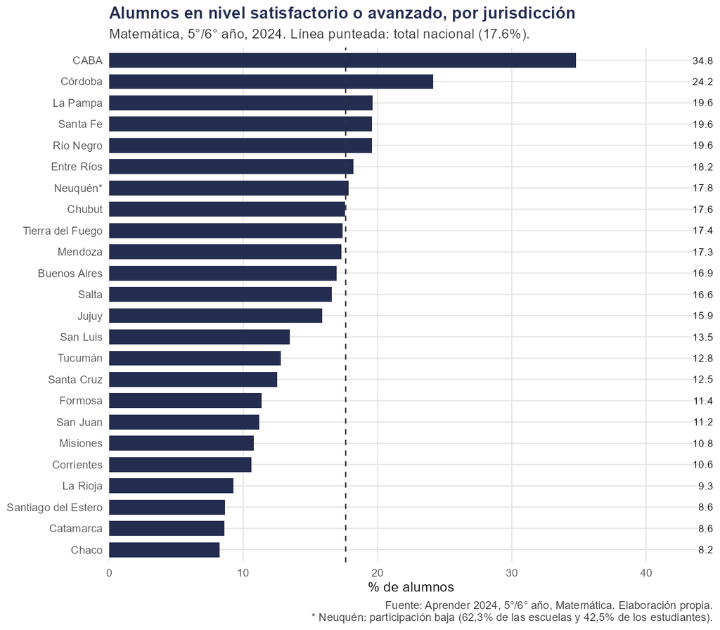

## 6.2 Brecha entre escuelas privadas y estatales

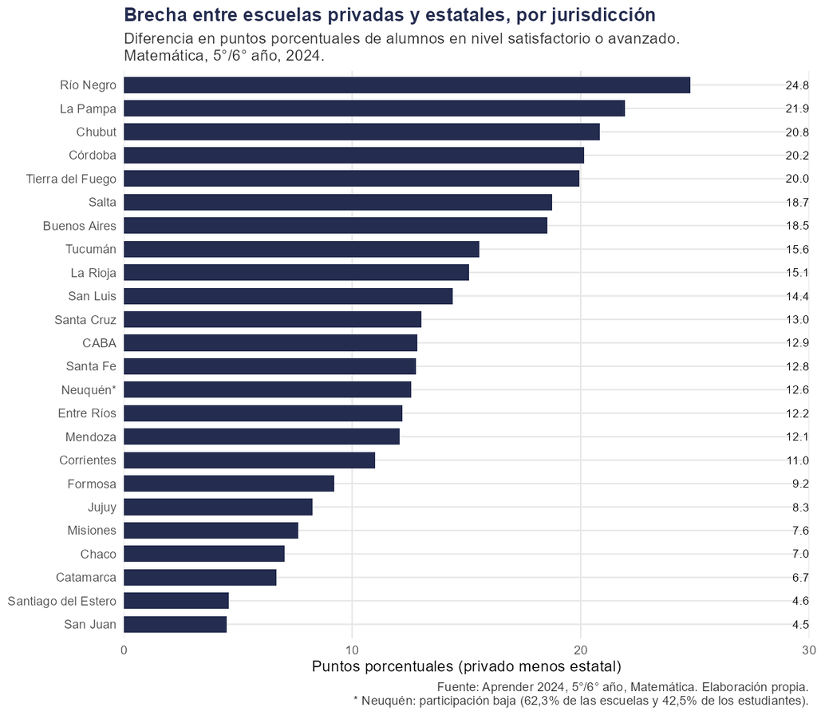

## 6.3 Brecha urbano-rural dentro del sector estatal

Solo para las 19 jurisdicciones con al menos 500 alumnos en cada estrato (quedan afuera CABA, La Pampa, Neuquén*, Tierra del Fuego, Santa Cruz).

| Jurisdicción | Urbano (%) | Rural (%) | Brecha urbano - rural (pp) |
| --- | --- | --- | --- |
| San Juan | 11,7 | 3,0 | 8,7 |
| Mendoza | 15,3 | 7,2 | 8,1 |
| Jujuy | 15,0 | 7,2 | 7,8 |
| Salta | 13,0 | 6,6 | 6,4 |
| Río Negro | 14,2 | 8,8 | 5,3 |
| Corrientes | 9,1 | 4,3 | 4,8 |
| Misiones | 8,9 | 4,4 | 4,6 |
| Santa Fe | 14,9 | 10,9 | 4,0 |
| Catamarca | 8,1 | 4,2 | 3,9 |
| Chaco | 7,0 | 3,3 | 3,7 |
| Tucumán | 8,5 | 5,0 | 3,5 |
| Córdoba | 15,0 | 13,6 | 1,3 |
| Entre Ríos | 14,5 | 13,3 | 1,2 |
| San Luis | 11,2 | 11,4 | -0,2 |
| Buenos Aires | 10,3 | 10,8 | -0,5 |
| Chubut | 14,0 | 14,7 | -0,7 |
| La Rioja | 6,4 | 8,4 | -2,0 |
| Santiago del Estero | 5,6 | 11,0 | -5,4 |
| Formosa | 9,0 | 15,4 | -6,4 |

En 6 de las 19 jurisdicciones, las escuelas estatales rurales tienen un porcentaje **mayor** que las urbanas. Es un patrón de los datos y no se interpreta: no se conocen la participación por ámbito ni qué escuelas componen cada estrato.

## 6.4 Ranking observado y estandarizado

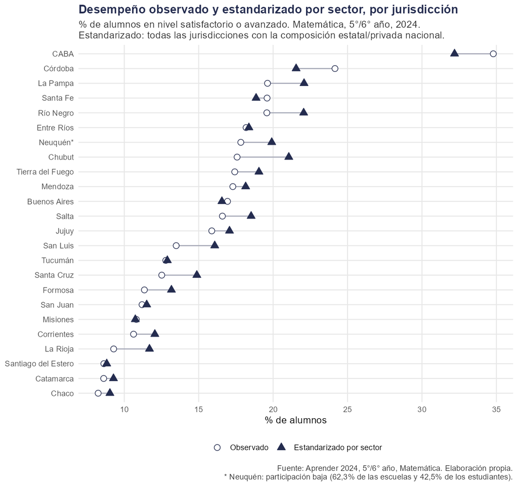

| Jurisdicción | Observado (%) | Estandarizado (%) | Efecto composición (pp) | Alumnos en privadas (%) | Puesto observado | Puesto estandarizado | Menos de 1 pp del siguiente |
| --- | --- | --- | --- | --- | --- | --- | --- |
| CABA | 34,8 | 32,2 | 2,6 | 53,7 | 1 | 1 | no |
| La Pampa | 19,6 | 22,1 | -2,5 | 22,2 | 3 | 2 | sí |
| Río Negro | 19,6 | 22,1 | -2,5 | 23,5 | 5 | 3 | sí |
| Córdoba | 24,2 | 21,5 | 2,6 | 46,4 | 2 | 4 | sí |
| Chubut | 17,6 | 21,1 | -3,5 | 16,8 | 8 | 5 | no |
| Neuquén* | 17,8 | 19,9 | -2,1 | 16,9 | 7 | 6 | sí |
| Tierra del Fuego | 17,4 | 19,0 | -1,6 | 25,3 | 9 | 7 | sí |
| Santa Fe | 19,6 | 18,9 | 0,7 | 39,2 | 4 | 8 | sí |
| Salta | 16,6 | 18,5 | -1,9 | 23,1 | 12 | 9 | sí |
| Entre Ríos | 18,2 | 18,4 | -0,2 | 31,9 | 6 | 10 | sí |
| Mendoza | 17,3 | 18,2 | -0,9 | 26,3 | 10 | 11 | no |
| Jujuy | 15,9 | 17,1 | -1,2 | 19,0 | 13 | 12 | sí |
| Buenos Aires | 16,9 | 16,6 | 0,4 | 35,5 | 11 | 13 | sí |
| San Luis | 13,5 | 16,1 | -2,6 | 15,5 | 14 | 14 | no |
| Santa Cruz | 12,5 | 14,9 | -2,4 | 15,3 | 16 | 15 | no |
| Formosa | 11,4 | 13,2 | -1,8 | 13,8 | 17 | 16 | sí |
| Tucumán | 12,8 | 12,9 | -0,1 | 32,8 | 15 | 17 | sí |
| Corrientes | 10,6 | 12,1 | -1,4 | 20,4 | 20 | 18 | sí |
| La Rioja | 9,3 | 11,7 | -2,4 | 17,5 | 21 | 19 | sí |
| San Juan | 11,2 | 11,5 | -0,3 | 26,5 | 18 | 20 | sí |
| Misiones | 10,8 | 10,7 | 0,1 | 34,3 | 19 | 21 | no |
| Catamarca | 8,6 | 9,3 | -0,7 | 23,6 | 23 | 22 | sí |
| Chaco | 8,2 | 9,0 | -0,8 | 22,2 | 24 | 23 | sí |
| Santiago del Estero | 8,6 | 8,8 | -0,2 | 29,2 | 22 | 24 |  |

* Neuquén: participación baja (62,3% de las escuelas y 42,5% de los estudiantes).

## 6.5 Sensibilidad

| Especificación | Jurisdicciones | Correlación de Spearman | Mayor cambio de puestos |
| --- | --- | --- | --- |
| Principal: 2 estratos, pesos nacionales (24) | 24 | 0,957 | 4 |
| 2 estratos, pesos iguales (24) | 24 | 0,949 | 5 |
| 2 estratos, composicion de Buenos Aires (24) | 24 | 0,956 | 4 |
| 3 estratos, pesos nacionales (19 elegibles) | 19 | 0,954 | 3 |
| 2 estratos sin CABA (23) | 23 | 0,952 | 4 |
| 2 estratos sin Neuquén (23) | 23 | 0,961 | 3 |

El resultado general se mantiene en un rango estrecho entre especificaciones: la correlación va de 0,95 a 0,96.

# 7 Limitaciones

1. **Estandarización solo por sector**: no se ajusta por nivel socioeconómico ni por ámbito, así que quedan diferencias de contexto sin controlar.
2. **Sin intervalos de muestreo**: la base viene agregada y ponderada. Los rankings cercanos no son distinguibles.
3. **Participación**: respondió el 70,2% de los estudiantes, y en algunas jurisdicciones mucho menos (Neuquén, 42,5%). No se evaluó el sesgo por no respuesta.
4. **Pesos de 2024**: dependen de la composición nacional de esa edición.
5. **Ponderadores**: las bases ya vienen ponderadas, y no se leyó el documento que explica qué representan los pesos.
6. **Foto de un año**: no dice nada sobre evolución, y no se compara con la primaria.
7. **Nivel avanzado casi inexistente**: el indicador es en la práctica “satisfactorio”.
8. **Descriptivo**: nada de lo anterior debe leerse como efecto de la gestión, de una política o de la calidad de una jurisdicción.

# 8 Reproducibilidad

El código, el diseño del análisis (con todas las reglas fijadas antes de calcular la estandarización) y las instrucciones de descarga están en el repositorio. Para regenerar este informe:

```
Rscript R/01_carga.R
Rscript R/02_auditoria.R
Rscript R/03_indicadores.R
Rscript R/04_estandarizacion.R
quarto render reports/informe.qmd
```

```
Versión de R: R version 4.6.0 (2026-04-24 ucrt)
```

```
dplyr 1.2.1 | readr 2.2.0 | knitr 1.51
```